# Figure 3 With Consumer-Resource Simulations

```r
rm(list = ls())

library(tidyverse)
library(patchwork)
library(ggdist)
library(ranger)
library(scales)
```

# Consumer-Resource Simulation Results

This document recreates the structure of Figure 3 from `extended_results.qmd`, but uses the consumer-resource simulation results in `resource_consumer/factorial2/community_measures.RDS`.

For the consumer-resource model, the main CPC metric used here is the binary viability CPC. This follows the consumer-resource report in this repository, where viability is treated as the abundance-relevant link between species-level temperature responses and total community abundance.

```r
cr_folder <- normalizePath(
  file.path("..", "resource_consumer", "factorial2"),
  mustWork = TRUE
)

community_measures <- readRDS(file.path(cr_folder, "community_measures.RDS")) |>
  as_tibble()

analysis_data <- community_measures |>
  mutate(
    resource_specialization = as.numeric(resource_specialization),
    resource_specialization_f = factor(resource_specialization)
  ) |>
  filter(
    is.finite(CV_totab),
    is.finite(CV_community_viability_binary_info),
    is.finite(CV_community_viability_binary_naive),
    is.finite(real_mean_b_opt),
    is.finite(real_sd_b_opt),
    is.finite(resource_specialization),
    is.finite(richness)
  )

n_cases <- nrow(analysis_data)
n_specialization <- n_distinct(analysis_data$resource_specialization)
```

The rendered figure uses 10125 valid consumer-resource simulation cases across 5 resource-specialization levels.

## Explanatory Power By Resource Specialization

```r
models <- list(
  actual = as.formula("CV_totab ~ CV_community_viability_binary_info"),
  null = as.formula("CV_totab ~ CV_community_viability_binary_naive"),
  trait_summaries = as.formula("CV_totab ~ abs(20 - real_mean_b_opt) * real_sd_b_opt")
)

safe_lm_r2 <- function(formula, data) {
  fit <- tryCatch(lm(formula, data = data), error = function(e) NULL)

  if (is.null(fit)) {
    return(NA_real_)
  }

  r2 <- summary(fit)$r.squared

  if (is.finite(r2)) {
    r2
  } else {
    NA_real_
  }
}

results <- analysis_data |>
  group_by(resource_specialization, env_series_id, u_opt_mean) |>
  group_modify(~ {
    map_df(
      models,
      function(formula, data) {
        tibble(
          r2 = safe_lm_r2(formula, data),
          df_red = nrow(data) - length(coef(lm(formula, data = data)))
        )
      },
      data = .x,
      .id = "model"
    )
  }) |>
  ungroup() |>
  filter(is.finite(r2)) |>
  mutate(
    model = factor(
      model,
      levels = c("actual", "null", "trait_summaries"),
      labels = c(
        "Actual",
        "Null",
        "Trait summaries"
      )
    ),
    resource_specialization_f = factor(resource_specialization)
  )

panel_a <- ggplot(results, aes(x = resource_specialization_f, y = r2)) +
  geom_point(
    position = position_jitter(width = 0.05, height = 0),
    aes(colour = resource_specialization_f),
    alpha = 0.30,
    size = 3
  ) +
  stat_halfeye(
    side = "left",
    aes(fill = resource_specialization_f),
    color = "black",
    slab_alpha = 0.25,
    interval_alpha = 1,
    point_alpha = 1,
    .width = c(0.5, 0.8),
    adjust = 0.8,
    justification = 1.05,
    point_interval = "median_qi"
  ) +
  scale_fill_viridis_d(option = "C", end = 0.95) +
  scale_colour_viridis_d(option = "C", end = 0.85) +
  coord_cartesian(ylim = c(0, 1)) +
  facet_grid(
    ~ model,
    labeller = as_labeller(c(
      Actual = "CV of actual binary\nviability CPC",
      Null = "CV of null binary\nviability CPC",
      "Trait summaries" = "Trait summaries"
    ))
  ) +
  theme_bw(base_size = 20) +
  theme(
    legend.position = "none",
    panel.grid.minor = element_blank(),
    panel.grid.major = element_line(color = "grey92"),
    strip.text = element_text(face = "bold")
  ) +
  labs(
    x = "Resource specialization (lambda)",
    y = expression(paste("Explanatory power of community metric (", R^2, ")"))
  )
```

## Random Subsets

```r
comm_data <- analysis_data

set.seed(123)
n_groups <- min(1500L, max(1L, floor(nrow(comm_data) / 25L)))

comm_r2 <- comm_data |>
  mutate(rand_group = sample(rep(seq_len(n_groups), length.out = n()))) |>
  group_by(rand_group) |>
  summarise(
    n_pairs = sum(
      !is.na(CV_totab) &
        !is.na(CV_community_viability_binary_info)
    ),
    r_sq = if (n_pairs >= 2) {
      cor(
        CV_totab,
        CV_community_viability_binary_info,
        use = "complete.obs"
      )^2
    } else {
      NA_real_
    },
    .groups = "drop"
  ) |>
  filter(is.finite(r_sq))

mean_r2 <- mean(comm_r2$r_sq, na.rm = TRUE)
median_r2 <- median(comm_r2$r_sq, na.rm = TRUE)

panel_b <- ggplot(comm_r2, aes(x = r_sq)) +
  geom_histogram(
    aes(y = after_stat(density)),
    bins = 40,
    fill = "#3B5C7A",
    color = "white",
    alpha = 0.8
  ) +
  geom_density(color = "#1A2E40", linewidth = 1) +
  geom_vline(xintercept = median_r2, linetype = "dashed", linewidth = 0.8) +
  annotate(
    "text",
    x = median_r2,
    y = Inf,
    label = paste("Median =", round(median_r2, 3)),
    hjust = -0.05,
    vjust = 1.4,
    size = 4
  ) +
  theme_bw(base_size = 16) +
  labs(
    title = "Distribution of Model Performance",
    subtitle = paste("Based on", n_groups, "random subset iterations"),
    x = expression(Explanatory~Power~(R^2)),
    y = "Density"
  ) +
  scale_x_continuous(limits = c(0, 1), breaks = seq(0, 1, 0.2))
```

## Random Forest

```r
set.seed(123)

rf_data <- analysis_data |>
  select(
    CV_community_viability_binary_info,
    CV_community_viability_binary_naive,
    resource_specialization,
    richness,
    CV_totab,
    real_mean_b_opt,
    real_sd_b_opt
  ) |>
  drop_na()

rf <- ranger(
  CV_totab ~ .,
  data = rf_data,
  importance = "permutation",
  num.trees = 1000,
  mtry = floor(sqrt(ncol(rf_data) - 1))
)

importance_labels <- c(
  CV_community_viability_binary_info = "Actual binary viability CPC",
  CV_community_viability_binary_naive = "Null binary viability CPC",
  resource_specialization = "Resource specialization",
  richness = "Species richness",
  real_mean_b_opt = "Mean thermal optimum",
  real_sd_b_opt = "SD thermal optimum"
)

importance_data <- tibble(
  Variable = names(rf$variable.importance),
  Importance = as.numeric(rf$variable.importance)
) |>
  mutate(
    Label = recode(Variable, !!!importance_labels),
    Label = fct_reorder(Label, Importance)
  ) |>
  arrange(desc(Importance))

panel_c <- ggplot(importance_data, aes(x = Label, y = Importance)) +
  geom_segment(aes(xend = Label, y = 0, yend = Importance), colour = "grey55") +
  geom_point(size = 3, colour = "#3B5C7A") +
  coord_flip() +
  theme_bw(base_size = 16) +
  theme(panel.grid.minor = element_blank()) +
  labs(
    title = "Feature Importance (Permutation)",
    x = "Predictor variables",
    y = "Importance (Increase in MSE)"
  )

rf_results <- rf_data |>
  mutate(predicted = rf$predictions)

panel_d <- ggplot(rf_results, aes(x = predicted, y = CV_totab)) +
  geom_point(alpha = 0.4, color = "#3B5C7A") +
  geom_abline(
    slope = 1,
    intercept = 0,
    linetype = "dashed",
    color = "red"
  ) +
  geom_smooth(method = "lm", color = "black", se = FALSE) +
  theme_bw(base_size = 16) +
  theme(panel.grid.minor = element_blank()) +
  labs(
    title = "Observed vs. Predicted",
    subtitle = paste("OOB R-squared:", round(rf$r.squared, 3)),
    y = "Observed instability\nCV(total abundance)",
    x = "Predicted instability (OOB)"
  )
```

# Figure 3, Consumer-Resource Version

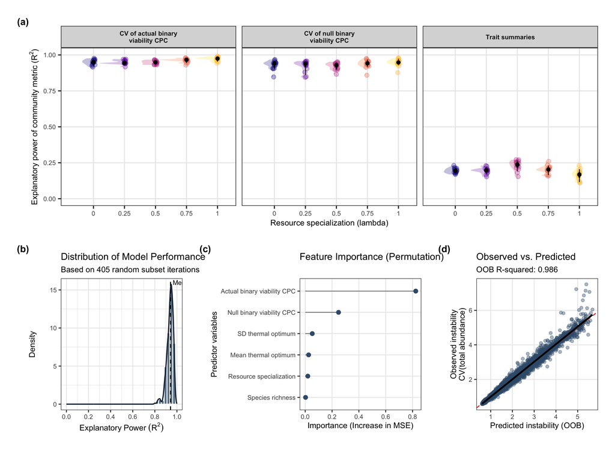

Figure 3, consumer-resource version. (a) Relationship between resource specialization and the explanatory power of community metrics in predicting instability, measured as the coefficient of variation of total consumer abundance. The first two panels use actual and null binary viability CPC metrics; the third uses trait summaries based on the distance of the realized mean species thermal optimum from the mean temperature and the realized standard deviation of species thermal optima. Points are grouped by resource specialization, temperature time series, and mean uptake optimum. (b) Robustness of the relationship between binary viability CPC variability and instability across random subsets of the data. (c) Permutation importance from the random forest model. (d) Observed versus out-of-bag predicted instability from the random forest model.